# Homework 8

Jonathan Hernandez

April 26, 2018

8.2

1. equation of regression line:

given the slope estimate of parity and the estimate of the y-intercept the equation is

weight = 120.07 – 1.93 parity

2. The slope -1.93 means for every child not first born, we expect to see the weight decrease by 1.93.

if a first born child that is parity = 0, then the average weight is 120.07 (assuming ounces or about 7.5 lbs)

if not a first born child that is parity = 1, then the average weight is 118.14 ounces

3. To see if the model shows a relationship between parity and birth weight, let’s

come up with a hypothesis

let $H_{0}$: $\beta$ = 0 and $H_{A}$: $\beta$ != 0

looking at the T value and p-value, the p-value is about 0.1 and thus it is not

significant enough or not enough to reject the null hypothesis and that whether a

child is first born or not doesn’t contribute to birth weight.

8.4

1. Equation of the regression line:

$\hat{absent}$ = 18.93 - 9.11$\hat{eth}$ + 3.10$\hat{sex}$ + 2.15$\hat{lrn}$

2. the slope $\beta_{1}$ = -9.11 means that it is predicted that a non aboriginal

child will be absent average 9.11 days assuming all variables constant.

the slope $\beta_{2}$ = 3.10 means that it is predicted that a male child will be

absent average 3.10 days assuming all variables constant.

the slope $\beta_{3}$ = 2.15 means that it is predicted that a child who is a

slow learner will be absent average 2.15 days

3. the Residual is calculated as $e = y - \hat{y}$.

in this case, y = 2 days and computing $\hat{y}$ from the model in a) gives

$\hat{y}$ = $\hat{absent}$ = 18.93 - (9.11$*$ 0) + 3.10$*$ 1 + 2.1$*$ 1 = 24.13 days

e = 2 - 24.13 = -22.13

4. The Calculated $R^2$ and Adjusted $R^2$ can be calculated using the formulas

below:

$R^2$ = 1 - var(e) / var(y) where var(e) is the variance of the residuals which

in this problem is 240.57 and var(y) is the variance of the outcomes which is

264.17

Plugging in the numbers gives $R^2$ = 1 - 240.57/264.17 = 0.089

likewise finding $R^2_{adj}$ = $R^2$*(n-1/(n-k-1)) where n is the total number of

observations and k is the number of predictor variables n = 146 and k = 3 which

gives $R^2_{adj}$ = 0.089 * (145/142) = 0.091

8.8

Using backward elimination, we first start by looking at the variable with the highest adjusted $R^2$ which would be in this case the “No learner status” variable as it has the highest adjusted $R^2$ of 0.0723.

8.16

1. One thing that I’ve noticed in the dataset is that the higher temperature around 66 Fahrenheit there are hardly no damaged O-rings and hardly none above 70 degrees Fahrenheit.
2. Looking at the table, we see that the y-intercept is estimated to be 11.6630 and the slope to be -0.2162. The slope means for each temperature change we expect the probability to decrease by a factory of 0.2162. The p-value for the estimates is near 0 which may indicate strong evidence to reject the null hypothesis and favor the alternative.
3. The logistic model is:

$logit(p/ 1- p) = 11.6630 – 0.2162*Temperature$

4. The model should be able to classify as temperature increases, the probability should be close to 0 meaning that there is no damaged O-rings and as the temperature decreases probability goes to 1 meaning the possibility of a damaged O-rings is likely. The model does moderately capture this notion.

8.18

1. Using the model $logit(p/1-p) = 11.6630 – 0.2162*Temperature$ and that

Temperature = 51: p_51 = exp(11.6630-0.2162$*$ 51) / 1 + exp(11.6630-0.2162$*$51) = 0.654

Temperature = 53: p_53 = exp(11.6630-0.2162$*$ 53) / 1 + exp(11.6630-0.2162$*$53) = 0.551

Temperature = 55: p_55 = exp(11.6630-0.2162$*$ 55) / 1 + exp(11.6630-0.2162$*$55) = 0.443

2. Using the given model probabilities plot them:

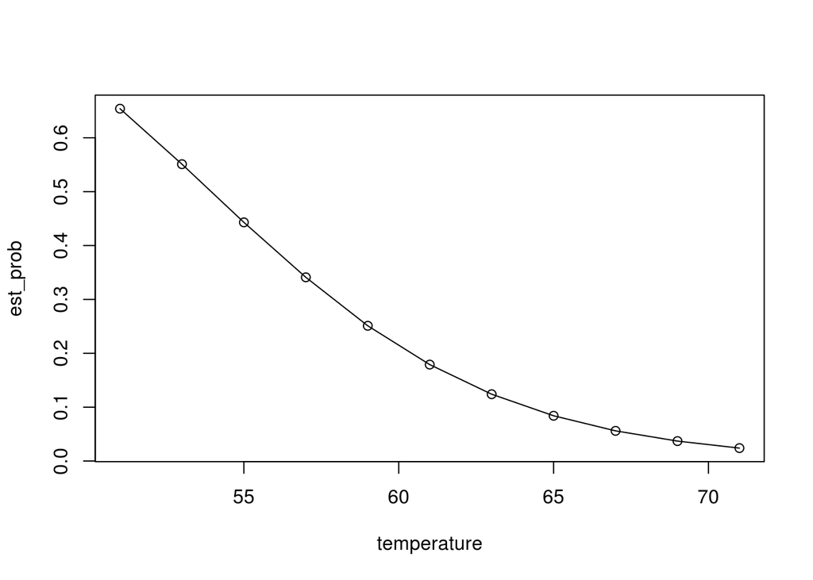

```r
temperature <- c(51, 53, 55, 57, 59, 61, 63, 65, 67, 69, 71)
est_prob <- c(0.654, 0.551, 0.443, 0.341, 0.251, 0.179, 0.124, 0.084, 0.056, 0.037, 0.024)
plot(temperature, est_prob, type = 'o')
```